# Post‐Acquisition Restructuring as Evolutionary Process*

Converted from PDF `Meyer-PostAcquisitionRestructuring-2003-JMS.pdf` · 24 pages · anchors: page `#pN`, block `#pN-bK`

Page 1

### **Post-Acquisition Restructuring as Evolutionary Process***

### **Klaus E. Meyer and Enese Lieb-Dóczy**

*Copenhagen Business School; N.E.R.A., London*

 The transformation and integration of acquired businesses is subject to tensions between implementing radical change to match the strategy and corporate culture of the acquirer, and promoting what is valuable in resources and cultural attributes in the acquired organization. Analysts’ disagreement arises from different conceptualizations of the nature of resources. We present an evolutionary perspective that demonstrates not only the merits of competitive selection, but of local adaptation of transferred resources and of stimulating the development of local ones.

Evidence from 18 original case studies in Hungary and East Germany shows that a defensive focus on short-term efficiency, i.e. downsizing, may fail to realize the longterm potential of the organization. Acquirers supporting an evolutionary development of their new subsidiary by providing autonomy and complementary resources might well have to tolerate some slack in the short run, but may realize more of the potential contributions of the acquired assets in the long run.

#### **INTRODUCTION**

The transformation and integration of acquired businesses is subject to tensions between implementing radical change to match the strategy and corporate culture of the acquirer, and preserving what is valuable in resources and cultural attributes in the acquired organization. The preservation and enhancement of local resources and experience easily conflicts with the objective of creating efficient integrated multinational operations. This is arguably especially the case for Central and Eastern Europe (CEE), where local organizations search for new ways to face the challenges of a nascent competitive market economy (e.g. Newman, 2001; Stiglitz, 1999). Resource endowments and institutions are different from those in mature market economies, which calls for new theoretical approaches to explain

*Journal of Management Studies* 40:2 March 2003 0022-2380

*Address for reprints*: Klaus E. Meyer, Copenhagen Business School, Howitzvej 60, 2000 Frederiksberg, Denmark (km.cees@cbs.dk).

© Blackwell Publishing Ltd 2003. Published by Blackwell Publishing, 9600 Garsington Road, Oxford, OX4 2DQ, UK and 350 Main Street, Malden, MA 02148, USA.

Page 2

corporate strategies under the specific conditions (Hoskisson et al., 2000; Peng, 2000). Foreign acquirers are confronted with conflicts between continuity and change when integrating and restructuring acquired organizations. In this paper, we study the reconfiguration of resources and capabilities during enterprise transformation (ET) on the basis of the resource-based theory of the firm (Barney, 1991; Dierickx and Cool, 1989; Wernerfelt, 1984). Haspeslagh and Jemison (1991) argue that a resource- (or capabilities-) based perspective aids understanding of the integration process, and its interdependence with the specific resources of acquirer and acquisition target. We focus on dynamic dimension of post-acquisition management, applying an evolutionary perspective developed in the management literature (Kogut and Zander, 1993, 1996; Spicer et al., 2000). The use of evolutionary analysis for economic transition has been suggested by a diverse range of scholars such as Grabher and Stark (1996), Kogut (1996), Murrell (1992), and Hendley (1998), who conducted field research in the region. We thus depart from the dominant agency-based theoretical framework employed by economists analysing enterprises in transition.

Enterprise transformation strategies have to account for the evolutionary nature of the process and the development of new capabilities. Foreign investors entering this environment need a strategy to initiate the dynamic processes of integrating resources and capabilities to generate specific solutions for the local context, and to enhance their own global capabilities.

The research on foreign acquisitions in Hungary and East Germany utilized by this paper (Lieb-Dóczy, 2001) suggests that with some degree of managerial autonomy and access to complementary resources, firms perform better in terms of generating innovative solutions for the local context, and new capabilities for use in the investor’s worldwide operations. Acquirers that allowed local decision-makers and research units to pursue indigenous strategies performed better in terms of the development of product and process innovations, and utilization of acquired resources. These subsidiaries evolved by expanding both their ‘charter’ and their capabilities (Birkinshaw and Hood, 1998). On the other hand, focus on short-term efficiency, e.g. by downsizing, may destroy valuable human capital and employee motivation, and thus fail to realize the long-term potential of the organization. We observed that the objectives of overcoming inertia and of preserving and developing indigenous capabilities led to conflicts, with most investors paying only secondary attention to the latter.

In presenting these results, we are making the following contributions. We argue that the resource-based view is suitable to analyse post-acquisition integration in an emerging market context, where adaptations may have to be more extensive, but are less well understood by managers in corporate headquarters. To this end, we demonstrate that the evolutionary perspective sharpens the insights and implications of the resource-based literature. Our analysis of a unique set of case studies

460 K. E. Meyer and E. Lieb-Dóczy

© Blackwell Publishing Ltd 2003

Page 3

(Lieb-Dóczy, 2001) shows the potential pitfalls of ignoring the fact that organizational change is an evolutionary process. We call for further research on the concept of evolution in the management literature to understand evolutionary processes *within* firms. The empirical work for this paper was done by Enese Lieb- Dóczy and is published in detail in Lieb-Dóczy (2001).

This paper is structured as follows. The second section introduces our theoretical arguments concerning ET based on the industrial organization and evolutionary literature. The third section introduces the cases and methods of analysis. The fourth section analyses the role of foreign investors and managerial decisions in the restructuring process, given external constraints. The final section summarizes and suggests implications relevant beyond CEE.

#### **THEORETICAL PERSPECTIVES**

In the socialist regime, firms were established to produce goods or services as specified by the central plan. Their dominant logic (Bettis and Prahalad, 1986) was geared towards the overriding objective of plan-fulfilment, and included full employment and individual obedience (Newman, 2000). The incentives created by central planning led, however, to severe distortions, such as the production of large volumes of standardized low quality products, lack of concern for consumer demand, and disregard for externalities. Firms employed far more people than necessary to achieve their output targets and provided many social services to both current and retired employees. The prime concern of management was to implement the central plan, while few incentives, or in fact opportunities, encouraged product or process innovation (Kornai, 1980).

As this brief characterization illustrates, firms have a very different role in socialist and in capitalist societies. The transformation process thus involves simultaneous changes along multiple dimensions. Theorists of different academic disciplines and traditions have focused different aspects. We contrast the economic perspective common among Western advisors in the 1990s with a resource-based, evolutionary approach.

#### **An Industrial Organization Perspective**

Economics research of firms in transition has primarily been concerned with the incentive structures facing managers and employees, and use agency-theory to analyse the implications of different forms of ownership and corporate governance (Filatochev et al., 2000; Roland, 2001). In this research, firms are conceptualized as bundles of production factors that are combined to optimize efficiency for given production functions and market prices. Most economic analysts of transition focus on enterprise transformation as a move from an inferior state to a superior equilibrium. They are thus primarily concerned with the outcome in terms of pro-

Post-Acquisition Restructuring 461

© Blackwell Publishing Ltd 2003

Page 4

ductivity and profitability (e.g. Claessens et al., 1997; Jones et al., 1998) but pay only scant attention to the dynamics of the process.

ET is primarily seen as a matter of reconfiguring the production process. Policy advisors trained in this tradition emphasize closing down unprofitable production lines, changing inputs and outputs, and redrawing the boundaries of the firm based on transaction costs considerations (Roland, 2001). The initial defensive restructuring of local firms applied these ideas primarily by downsizing (Brada, 1996). While improving their productivity, firms rarely progressed to strategic restructuring.

In some cases, a cost-leadership strategy with focus on production efficiency, low labor costs and a technically skilled workforce has been successful. These firms pursued a more rigorous application of what during socialism was called ‘scientific management’, the sophisticated division of labor in the production process along Taylorist principles (Sorge, 1993). Although this mode of organizing has been replaced in most Western industries, some firms restructured their operations to reduce costs by more precise division between skilled and unskilled workers and more rigorous supervisory control, without developing substantive new capabilities. Whitley and Czaban (1998b) and Taplin and Frege (1999) find cases that, in the short-term, show above average productivity and profitability.

Yet laying off excess resources is only one way to improve productivity. Firms bringing in complementary capabilities can increase productivity of the inherited resources. In transition countries, they can take advantage of their catch-up situation and import better practices and technologies that have been developed in the West.

However, at crucial stages resource acquisition has been constrained by limited financial resources as well as lack of absorptive capacity and knowledge as to what resources would best complement existing ones. Due to these constraints, few firms other than those acquired by foreign investors or participating in international joint-ventures have progressed to strategic restructuring. Empirical research confirms that foreign investment firms outperform domestic ones (Carlin et al., 1995; Fahy et al., 2000) and that post-acquisition investment enhances performance (Uhlenbruck and De Castro, 2000).

The realignment of firm resources to increase productivity is thus at the centre of most restructuring strategies recommended for acquisitions in transition economics. The economics of transition literature thus provides the notions of defensive and strategic restructuring for our analysis (Brada, 1996; Lieb-Dóczy, 2001; Meyer, 1998b). Both defensive and strategic restructuring should have a positive impact on firm performance, even if only after a time lag of, say, three to five years. In this medium term, we thus expected that (a) the shedding of redundant resources, i.e. separation from non-core assets and excess employment and (b) acquisition of complementary assets through investment, training, and upgrading of product range and production technology, would positively impact upon firm performance.

462 K. E. Meyer and E. Lieb-Dóczy

© Blackwell Publishing Ltd 2003

Page 5

In our case research detailed below, we found the categories of defensive and strategic useful to classify firms at different stages of their restructuring. Yet this classification was of little use in explaining medium or long-term performance.

#### **ET as Evolutionary Phenomenon**

The economics framework outlined above has been the starting point for our analysis of restructuring in the case firms. With the evidence from the field, however, we realize that this approach is by far insufficient to explain what we were observing. We thus follow Yin’s (1994) and Eisenhardt’s (1989) advice to reassess our theoretical priors. We realize that a dynamic theoretical framework is called for. In particular, we need to understand what happens inside a firm that drastically repositions itself in a changing environment. As Murrell (1992), Grabher and Stark (1996) and Hendley (1998) have suggested before, we find evolutionary theories to be more helpful in explaining what happened in enterprises in transition economics.

In the following, we present such a dynamic framework drawing in particular on the theoretical work on capabilities (Amit and Schoemaker, 1993; Kogut and Zander, 1996; Dosi et al., 2000; Eisenhardt and Martin, 2000), which has grown out of the resource-based view of the firm (Barney, 1991; Dierckx and Cool, 1989; Wernerfelt, 1984). We then present the case evidence, and argue why we find this evolutionary perspective more suitable than the industrial organization perspective to explain the transformation of acquired firms.

In the first step, we had to reassess our concept of ET. The transition ‘from plan to market’ (World Bank, 1996) is a fundamental change of both the rules of the game and performance criteria (Meyer, 2001; Newman, 2000). The new rules themselves evolve, in fact, over several years, creating a transition period of high uncertainty. To achieve competitiveness under the new conditions, firms have to change not only their resource configurations, and their skill and capability reservoirs, but also the ways of organizing themselves and of interacting with the environment. ET involves simultaneous change along all these dimensions. Therefore, we take as point of departure our own process-oriented definition of enterprise transformation:

Enterprise transformation (ET) is the process of changing an organization previously adjusted to perform according to the performance criteria and rules of the game of the real existing socialism to perform competitively according to the performance criteria and rules of the game of a market economy.

Management scholars have long acknowledged the evolutionary nature of change processes within organizations (e.g. Tushman and Romanelli, 1985). In particular, the term ‘evolutionary’ has been used to describe and analyse the allocation and reallocation of charters to divisions (Galunic and Eisenhardt, 1996) and sub-

Post-Acquisition Restructuring 463

© Blackwell Publishing Ltd 2003

Page 6

sidiaries (Birkinshaw and Hood, 1998). An international acquisition creates a new subsidiary that needs to be integrated in the firm, and subsequently participates in the charter allocation process. Haspeslagh and Jemison (1991, p. 15) thus recommend ‘for value creation to be realized, integration must be seen as an evolutionary process of adaptation, rather than as a completely predictable, planned activity’. Integration management thus has to incorporate the trade-off between speed and the quality of the integration in terms of utilizing the potential of the local operation without alienating its key personnel (Cartwright and Cooper, 1996; Haspeslagh and Jemison, 1991).

Divergent opinions on post-acquisition management often reflect different conceptualizations of the nature of resources. The resource-based view uses broad concepts of resources to include intangible capabilities. These capabilities are embedded in individuals and teams, in the firm’s internal and external network relationships, in its business processes and in synergies realized between business units (Dierickx and Cool, 1989; Kogut and Zander, 1993; Teece et al., 1997). The concept of ‘dynamic capabilities’ (Eisenhardt and Martin, 2000; Teece et al., 1997) extends the term ‘routines’ used in evolutionary economics. Routines connote ‘behavior that is conducted without much explicit thinking about it, as habit or customs . . . [or] as the behaviors deemed appropriate and effective in the settings where they are invoked’ (Nelson, 1995, p. 68). Dynamic capabilities are based on such routines. They are ‘the firm’s processes that use resources . . . to match and even create market change. Dynamic capabilities thus are the organizational and strategic routines by which firms achieve new resource configurations as markets emerge, collide, split, evolve, and die’. (Eisenhardt and Martin, 2000, p. 1107).<sup>[1]</sup>The capabilities of a firm are the outcome of past selection processes, and embody organizational knowledge.

A radical change, like that induced by economic transition, requires firms to build new capabilities. In turn, individuals in the organizations have to change their routines, their patterns of interaction, and possibly even attitudes and value systems (Meyer and Møller, 1998). Building new capabilities in an existing organization is an evolutionary process that is driven by the processes of knowledge generation and organizational learning. Organizations evolve, rather than reincarnate themselves overnight, when facing change in their environment or ownership. They evolve ‘through the recombination of knowledge, . . . partly by the generative logic of their capabilities but also by the opportunities and influences of the external environment’ (Kogut and Zander, 1996, p. 503).

A stream of literature within the resource-based view that provides insights on how routines are changed is the organizational learning theory (Argyris and Schoen, 1978; Huber, 1991; March, 1991). Learning occurs in organizations through routines that are repeated and modified (Levitt and March, 1988) and schemas, or mental maps, which determine how information is interpreted (Bettis

464 K. E. Meyer and E. Lieb-Dóczy

© Blackwell Publishing Ltd 2003

Page 7

and Prahalad, 1986). Most organizational learning is incremental change in routines within existing schema. Yet, the change required in firms in CEE following the institutional upheaval of the early 1990s requires deeper, second-order change (Newman, 2000) that in turn requires ‘second-order learning’ (Lant and Mezias, 1992) or learning through ‘exploration’ (March, 1991). Successful learning is firstly a function of the firm’s absorptive capacity (Cohen and Levinthal, 1990), that is their ability to adopt knowledge in their environment, connect it with existing knowledge and routines and thus apply it for their purposes. For formerly socialist firms coming into contact with Western business practice, this has often been a crucial constraint (Lyles and Salk, 1996). In part this is due to the very large gap between existing routines and potential new routines (Newman, 2000). Firms lack suitable templates to adopt existing routines do not aid in developing them, and existing knowledge does not suffice to understand relevant cause-effect relations in their environment. Where suitable routines are lacking, firms have to engage in trial and error processes to explore and develop new routines. This period of experimentation is a crucial phase for firms facing an unfamiliar environment with new rules and performance criteria.

Learning is part of the evolutionary process of change, heading to the development and adoption, retention and selection of capabilities, conditioned by the specific environment. Innovative routines are adopted from outside or developed internally through a process of experimentation (Kogut, 1996). Innovation increases firms diversity, which is essential to create not only new and potentially superior routines, but also to retain those suitable to cope with periodically recurring adverse conditions. Diversity is valuable in its own right because it generates options for future development, and retains options to deal with unusual situations.<sup>[2]</sup>

The other side of the coin of evolution, and often the more familiar one, is selection. This occurs on multiple levels in both biological (Maynard Smith and Szathmáry, 1999) and social systems (Aldrich, 1999; Baum and Singh, 1994). Organizations are exposed to evolutionary processes vis-à-vis other organizations, yet their fitness is the outcome of internal evolutionary processes, selecting between, for instance, subcultures, business practices and individual employees. Firms with internal processes that generate and adopt superior capabilities are more ‘fit’ in terms of the evolutionary selection facing the firm itself.

Between firms, markets are the most important selection mechanism, except for highly regulated or politicized environments. Yet, this selection does not yield the superlative fittest, only the comparatively and tolerably fit under given environmental circumstances. Any present organization is the result of a selection process conditioned by its specific environment, and past shocks experienced by this environment. It is relative to this context that the organization is ‘fittest’.

In other words, fitness is always both relative to the competitors, and conditional on the environment, which itself may change during the selection process (Carroll

Post-Acquisition Restructuring 465

© Blackwell Publishing Ltd 2003

Page 8

and Harrison, 1994). An organization emerging as the ‘fittest’ under a particular economic, political and cultural context would not necessarily be the best under changing circumstances.

To sum up, change within firms is an *evolutionary process* with generation of new routines through *organizational learning*, and the *context-sensitive selection* between them. In case of radical change, such as in East European transition, this often requires second-order learning, i.e. search and development of entirely new routines, often by *experimentation.* New capabilities can incorporate a wide range of local and foreign knowledge and routines but have to accommodate the idiosyncrasies of the local context.

#### **An Evolutionary Perspective on Transition**

Evolutionary economists are concerned that the current reforms in transition economies are overly preoccupied with removing institutional legacies for the sake of freeing the competitive forces of markets along Western models (Kogut, 1996; Murrell, 1992). This results in the wholesale it importation of Western concepts, rules and institutions at both the national and organizational level. Few efforts have been spent on developing new solutions adapted to the transition context, which is characterized by weak and unstable institutions (and consequently high economic uncertainty) (Meyer, 2001; Newman, 2000). Thus neither inherited routines, nor those adopted from Western partners and consultants are suitable but new ones need to be developed. Hence, Kogut (1996) encourages firms to focus on learning through experimentation and the internal development of new capabilities adapted to the specific context, rather than the wholesale imposition of imported routines.

From an evolutionary perspective, transition has the potential of ‘creating variety and mutations emerging from the recombination of the inherited forms with emerging ones’ (Grabher and Stark, 1996, p. 6). If one were to optimize the process, one would face the trade-off between, on the one hand, generating alternatives and allowing them to develop – e.g. by limited and temporary protection – and, on the other hand, competitive selection.

Liberalizing industry in CEE too fast radically changes the competitive selection process (Spicer et al., 2000). If moreover the rules of engagement change at the same time, organizations face a double shock: not only do they face more competitors, but previously successful routines are useless against these competitors. In addition, the ensuing volatility promotes routines other than those that would fit best in a stable environment. If barriers were gradually lowered, organizational learning would permit firms in the temporarily protected country to become more competitive by the new, market-based rules of the game, before facing global competition (Spicer et al., 2000). They might then contribute more to the joint capability poo1 to create an even more productive world economy.

466 K. E. Meyer and E. Lieb-Dóczy

© Blackwell Publishing Ltd 2003

Page 9

#### **An Evolutionary Perspective on Post-acquisition Restructuring**

After an acquisition, the process of developing and selecting routines and capabilities is driven by the interaction with the new parent, and framed by the subsidiary charter (Galunic and Eisenhardt, 1996).<sup>[3]</sup> MNEs assign charters, not necessarily in written form, to their subsidiaries to describe their expected role within the firm’s network (Birkinshaw and Morrison, 1995). For newly acquired firms, the initial charter reflects the investor’s strategic intent that motivated the acquisition, as well as the presumed capabilities of the affiliate. This may be based on its known existing capabilities, or be more ambitious to anticipate development of the existing capabilities. In the long term, subsidiaries evolve so that capabilities and charter match (Birkinshaw and Hood, 1998).

The organizational learning process is crucially influenced by the investors’ integration strategies and determines the firm’s future resource and capability pool (Haspeslagh and Jemison, 1991). The transfer of knowledge is an opportunity to accelerate second-order learning by providing templates that can be adopted. However, it is constrained by the recipient organization’s ability to integrate received knowledge, i.e. its absorptive capacity (Cohen and Levinthal, 1990). Especially tacit knowledge requires active learning to connect it with prior routines and knowledge of recipients. This takes time.

Yet an incomplete absorption or an inappropriate adaptation to the local context may inhibit performance. Acquirers thus face a trade-off between promoting allocative efficiency in terms of the productivity of the acquired firm in the short term, and gaining the most of the potential inherent in the variety of capabilities, resources and organizational forms that now become part of their multinational corporation.

Moreover, post-acquisition integration requires organizational learning in both business units. The knowledge concerning the dominant logic of the new affiliate is highly tacit. Hence investors face obstacles in recognizing and assessing the capabilities of the organization, especially where they are embedded in teams, relationships or intangible assets – issues of particular relevance in the transition context. Many local practices may initially be perceived to be inferior, yet they may be better adapted to the environment.

Experimentation may be needed to develop new managerial practices that are in concordance with existing cultural values, resources, and routines (Kogut and Zander, 1996). Local capability development can be enhanced by providing access to resources and experiences of the MNE. New routines may eventually outperform the established ones yielding new worldwide ‘best practice’ for the MNE.<sup>[4]</sup>

Thus, investors may receive higher long-term benefits if the charter anticipates subsidiary development, setting ambitious long-term targets, providing autonomy and allowing for some degree of variety in managerial practice, organizational arrangements and technology.

Post-Acquisition Restructuring 467

© Blackwell Publishing Ltd 2003

Page 10

Acquired businesses with a high degree of autonomy and absorptive capacity can manage their learning themselves, promote knowledge exchange in both directions, and be selective in adapting the investor’s ‘best practices’. The need for autonomy increases with the extent of local idiosyncrasies, because utilization of local assets and sensitivity to local culture become more important.

Development of new capabilities, however, comes at a cost. Firms have to balance exploitative and explorative learning, yet they are inherently biased to neglect the latter as the former generates returns in the nearer future (March, 1991). High degrees of adaptation, of second-order learning, and diversity increase coordination costs within the MNE. Also, short-term efficiency targets may not be met. Hence we expect important *trade-offs* between the short and long term performance of the affiliate, and a non-linear relationship between financial *performance* and key integration strategy variables like *local adaptation* and *creation of new capabilities*.

#### **METHODOLOGY**

In-depth case studies published in Lieb-Dóczy (2001) were chosen to explore openended questions in the previously under-researched context of CEE, and the relations between the above-identified key concepts in particular. Lieb-Dóczy (2001) conducted 18 longitudinal case studies in East Germany and in Hungary,<sup>[5]</sup> two countries that heavily relied on foreign direct investment as means to privatize their economy (Meyer, 1998a). The cases represent acquisitions of large state-owned enterprises in manufacturing and construction with major restructuring challenges. Investors were chosen to reflect as wide a variation as feasible, especially by country of origin, to observe different approaches to restructuring.

Each case firm was visited up to three times in 1996 and 1997, and in total 48 managers and 16 trade union representatives were interviewed. The up to six interviews per firm lasted between one hour and two-and-half hours each, and were conducted in German. Hungarian or English according to the interviewee’s preference. A structured interview guide was used. The managers interviewed normally included board members responsible for purchasing, personnel and production as well as managing directors. Some were key Western expatriate managers, but most were local managers who had been with the organization since before its acquisition. In addition, we interviewed trade union representatives, which distinguishes this study from earlier ones and permits us to observe multiple perspectives on post-acquisition restructuring.

The interviews covered the history of the acquired firm, organizational and technological changes since its privatization, the relationship between the investor and the local firm, human resource management, regional and international integration, and changes in supplier relationships. In addition to interviews, a variety of secondary sources were obtained for the case firms, including annual reports,

468 K. E. Meyer and E. Lieb-Dóczy

© Blackwell Publishing Ltd 2003

Page 11

employee newsletters, newspaper reports, marketing materials, and other internal documents. Some firms had participated in case research at an earlier time. These case reports complemented our own data collection, strengthening the longitudinal dimension of this research. The findings in this paper were double checked against other recently published case studies in the same countries

Post-Acquisition Restructuring 469

© Blackwell Publishing Ltd 2003

Table I. The cases

[output not shown]

NOTE: table converted from PDF layout to HTML text; cell boundaries are reconstructed. See PDF if exact alignment matters.

*Notes* aAll names are pseudonyms to maintain anonymity. bMinority shareholder, majority held by privatization agency. cThe acquired firm performed poorly, the Treuhand bought it back, yet it later went bankrupt. dThe investor went bankrupt in 1995 and the Treuhand bought back the company. *Source* This table is based on Table 1.1 in Lieb-Dóczy (2001).

Page 12

470 K. E. Meyer and E. Lieb-Dóczy

© Blackwell Publishing Ltd 2003

Table II. Enterprise restructuring

[output not shown]

NOTE: table converted from PDF layout to HTML text; cell boundaries are reconstructed. See PDF if exact alignment matters.

Page 13

Post-Acquisition Restructuring 471

© Blackwell Publishing Ltd 2003

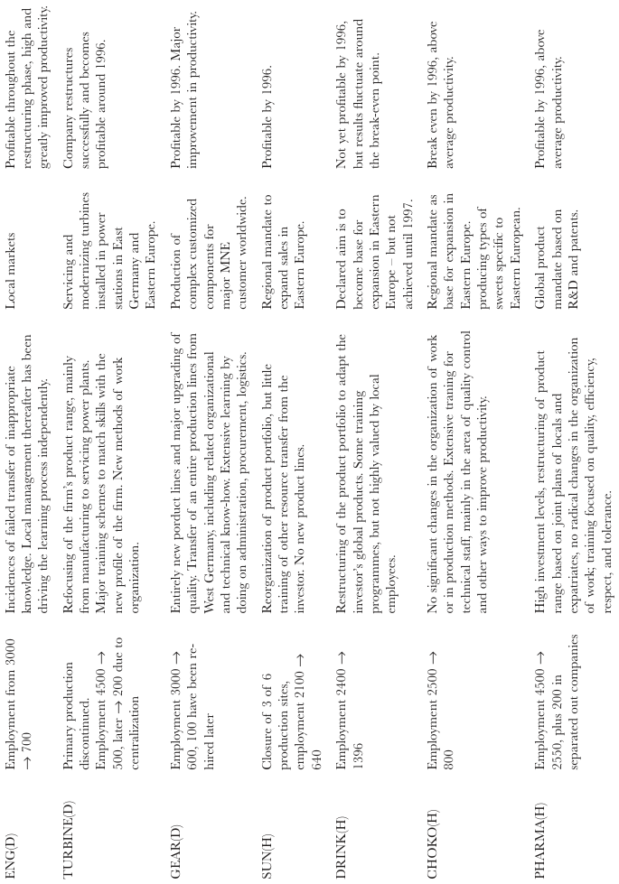

NOTE: complex table shown as an image of the PDF; the text below is a rough machine extraction and may be mis-aligned.

Page 14

472 K. E. Meyer and E. Lieb-Dóczy

© Blackwell Publishing Ltd 2003

Table II. *Continued*

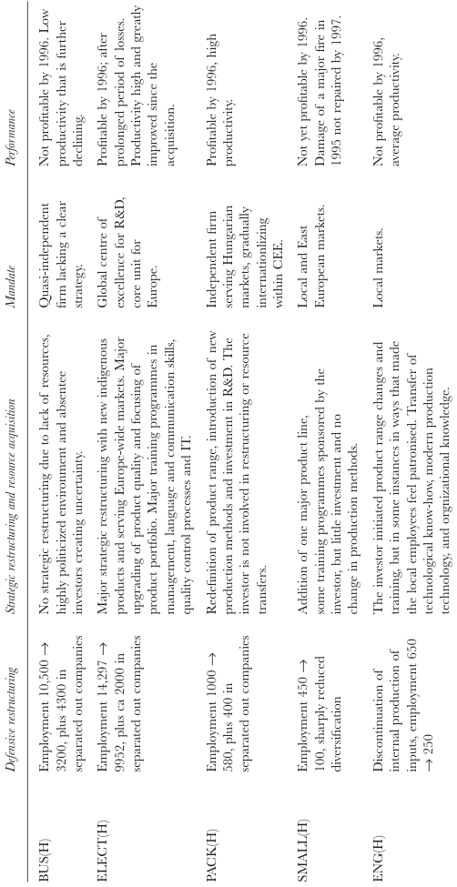

NOTE: complex table shown as an image of the PDF; the text below is a rough machine extraction and may be mis-aligned.

Page 15

(Antal-Mokos, 1998; Meyer and Møller, 1998; Whitley and Czaban, 1998a 1998b; Wolf, 2000).

The restructuring of enterprises is influenced by external factors, such as national politics and macroeconomic conditions, and internal factors that are under the control of management. In the empirical part of this paper, we focus on the latter as we look at the restructuring strategies pursued by investors that acquired the case firms (Lieb-Dóczy, 2001). Our qualitative analysis explores key concepts of the presented theory and illuminates some practical implications. However, first we have to briefly review the macro-context of the countries.

#### **COUNTRY EXPERIENCES**

Both Hungary and East Germany committed themselves soon after the fall of the Iron Curtain to privatize their state-owned firms by selling a large number of them to outside investors. Yet due to political and macroeconomic conditions, the institutions responsible for the ownership transfer had different priorities and means to manage firms under their control.

In East Germany, the ‘Treuhand’ Agency took an active approach to restructuring that effectively superimposed Western norms on existing organizations. Consequently, the German case firms show far more radical downsizing of employment and social services, which often happened before the foreign investors took over. At the same time, the Treuhand provided few resources for investment, thus effectively postponing strategic restructuring until after privatization. With disrupted business relations, and priority for Western structures and practices; firms had few opportunities to develop their own innovations (Kogut and Zander, 2000; Meyer and Møller, 1998). Most manufacturing firms among the German cases have adopted their investor’s organizational structure and management philosophy, and are integrated with their acquirers supply network, at the expense of disrupted local supply chains. Many produce niche products for Germany-wide markets and increasingly for export.

In Hungary, the shock was less severe. Consequently, we observe greater variety of ET, with both successes and failures. The Hungarian case firms show a remarkable degree of continuity in terms of product mix, production technology, and markets. Many firms have gone through an extended period of ‘organizational politicking’ (Antal-Mokos, 1998), which in most but not all cases ended with the privatization. After the acquisition, the Hungarian case firms experienced on average fewer changes in their corporate strategy and less tight integration with the investor than their German counterparts. Restructuring strategies focused more on investment and less on downsizing. Many firms continue to focus on local markets, and they engaged in less supplier switching.

Post-Acquisition Restructuring 473

© Blackwell Publishing Ltd 2003

Page 16

#### **MANAGEMENT CHALLENGES**

Our research initially focused on defensive and strategic restructuring, and its implications on corporate performance in the medium to long term. We report insights on these issues before describing observations concerning the change processes.

#### **Defensive and Strategic Restructuring**

Overall, we find supportive evidence on strategic restructuring and investment, while downsizing seems of dubious benefit. Why is that so? At the onset of transition, many firms employed considerably more people than necessary to produce their output. This ‘excess slack’ has been addressed by radical downsizing. Yet, many firms seem to have taken it too far. The short-term productivity improvements failed to translate into long-term productivity advantages. Downsizing has inherent risks arising from three sideeffects for which we found evidence in the cases:

• Downsizing can damage the social fabric of the organization and thus undermine employee motivation and cooperative values. Lay-offs had a traumatic effect on employee morale in several firms, since East European cultures have a norm of paternalistic leaders taking responsibility for their employees beyond a purely contractual principal-agent relationship (Michailova, 2000). In several cases, the investor reduced management layers and replaced local top managers with expatriates or young, Western-trained individuals. This was resented by the local workforce, e.g. in ENG(D) where employees associated themselves with competent local managers, and their firing led to widespread demotivation, as indicated by the local manager in charge of change in ENG(D):

474 K. E. Meyer and E. Lieb-Dóczy

© Blackwell Publishing Ltd 2003

Page 17

‘With every competent and respected old manager the investor sacked, the investor signalled to the workforce that they were regarded as useless as well. The workforce identifies with these managers, and thus is demotivated with every further manager being sacked.’ (Lieb-Dóczy, 2001)

• Downsizing can lead to the loss of people, or sale of assets, that are crucial for the firm’s core capabilities and resources. In fact, the very capabilities that could generate continuous improvement may be lost. For instance, displaced top managers take with them their knowledge of local markets and networks as well as of the organization and its technology. Expatriate managers were overruling locals, but later reversing their decisions (Lieb-Dóczy, 2001).

Rank and file employees also represent valuable human capital: GEAR(D) had to re-employ experienced ex-employees when demand revived. As redundancy payments are sunk costs, this was a costly mistake. POWER(D) experienced a significant aging of the workforce as lay-off procedures protected in particular those with a long affiliation to the firm. This reduced the flexibility and dynamism of the remaining workforce. • Downsizing can eliminate slack below the efficient level. While most firms undoubtedly had excess slack, its complete elimination may have been counterproductive. A certain degree of slack can be an important resource for innovation (Nohria and Gulati, 1996), for managerial learning, and thus for transformation. Some firms, notably in East Germany, seem to have cut the workforce to such an extent that no slack remained that could become a source for new growth. Several personnel managers and trade union representatives, notably in STEEL(D), POWER(D) and GEAR(D), pointed to this problem as they complained that time-constraints inhibit training at all levels.

To sum up, the cases fail to show a positive link between downsizing and performance, while pointing to several negative side effects. Also other studies failed to establish a link between post-privatization headcount reduction and performance (Andrews and Dowling, 1998). Hence the crucial strategic issue in restructuring is not *how much* a firm is downsized, but *how* downsizing helps to develop coherent core competences, and how the lay-offs are managed.

We thus conclude that downsizing, if handled inappropriately, can undermine the evolutionary process of capability development in the acquired organization. Local resources and capabilities, especially tacit ones not recognized by the investors, may be lost, while transferred resources cannot automatically integrate with, or substitute for local ones. In theory, it may be feasible to eliminate noncore assets and employees without losing valuable assets. Yet, in practice, we observe that short-term efficiency targets conflict with long-term capability building objectives.

Post-Acquisition Restructuring 475

© Blackwell Publishing Ltd 2003

Page 18

#### **Evolutionary Perspectives**

Among the successful firms, we observed incidences of active development of local resources, as well as superior integration of the two. On the other hand, failure could mostly be attributed to inertial forces and lack of resources, or failure of adapting and/or integrating resources. We review success cases first.

*Success cases.* The success of post-acquisition restructuring is hard to measure, because performance criteria vary with the strategic intent that motivated the acquisition. Some investors aimed at creating efficient marketing channels or an ‘extended workbench producing labour intensive goods at low costs. Local stakeholders interviewed were generally not content with this. Prior to 1990, many East European businesses possessed considerable indigenous capabilities that could be basis for a contribution beyond the local markets. Yet few accomplished it.

One indicator of success, at least from the perspective of local stakeholders, is the charter that the affiliate achieved. The cases include firms that were among the (technologically) best in their country. They thus ought to be capable of winning ‘global mandates’. Yet, few firms achieved global mandates as R&D or production site, or as core unit of the investor’s CEE market strategy. In the successful cases, a combination of strong local resources and initiative by local management were crucial success factors – as we would expect based on Birkinshaw and Morrison (1995). Periods of conflicts preceded the assignment of a global charter in ELECT(H) and to a lesser extend in GEAR(D), PHARMA(D) as the local management had to convince corporate headquarters of their capabilities, and the best way of utilizing them in a ‘local way’.

The case of ELECT(H) illustrates the potential of local resources, but also the dangers of insensitive and productivity focused restructuring. After the acquisition, the affiliate went through a major crisis during a period of downsizing. It lost market share in Western Europe and experienced serious internal conflicts that were widely debated in the national press. Key personnel left the firm. In 1992, an agreement was signed between the investor and the local employee representation, setting the stage for recovery and growth. The Hungarian affiliate became thc core of the investor’s European operation, while Hungarian research, provided with financial resources and a high degree of autonomy, presented a major product innovation. Today, ELECT(H) has a global mandate not only as a research centre, but in the investor’s pan-European marketing.

GEAR(D) achieved complete restructuring of their product range. The local management took initiative in 1990 by contacting the later investor, and they took over the day-to-day operations less than a year after the acquisition. Sixty per cent of their sales are now a specialized component for a leading car manufacturer. The company’s success is based on this major contract, heavy investment in the modernization of production, and comprehensive training for both technical staff and managers. PHARMA(D) also accomplished a global mandate as site of

476 K. E. Meyer and E. Lieb-Dóczy

© Blackwell Publishing Ltd 2003

Page 19

production and R&D and as the regional headquarters serving East European markets. The combination of strong technological capabilities and patents with knowledge transfer from the parent was crucial for this success.

*Unsuccessful cases.* Two broad causes of unsuccessful restructuring emerge in the case material. In one group of firms, inertia was allowed to inhibit substantive strategic restructuring. The second group suffered major set-backs from insufficient adaptation of strategies and routines to local idiosyncrasies. Some firms in this group revised their strategy later, and – at least – cut their losses.

The inertia developed from a combination of lack of transfer of resources, weak indigenous resources, political interference and internal politicking, similar to earlier studies (Hendley, 1998; Michailova, 1997). Local managers attributed inertia especially to their lack of resources (BUS(H), STEEL(D)). In most other cases, the Western investor has broken the inertia. However, in breaking with the past, several investors have ‘thrown out the good with the ugly’ superimposing their strategies, organizational structures and procedures with little adaptation to local context. Expatriate managers were often only superficially knowledgeable about local capabilities and organizational cultures. We found many examples where this led to flawed approaches to restructuring:

• Marketing strategies often emphasized global brands with little adaptation to local demand, distribution structures and cultures (see Schuh (2000) for a similar observation). Moreover, investors like DRINK(H) appeared unaware of idiosyncrasies of local demand. • Procurement became costly where an internal input production was closed, without considering the capabilities of alternative local suppliers. Companies, like PACK(H), that restructured input production by separating supply units into independent subsidiaries fared better than DRINK(H), SUN(H) who closed them altogether. • Managerial training designed in headquarters may fail to build on existing local capabilities and to address local needs. This was particularly evident in the case described by a local manager in ENG(D):

Post-Acquisition Restructuring 477

© Blackwell Publishing Ltd 2003

Page 20

‘One day we [the old management] got this letter from Austria notifying us that we should train people in the following software package. When we had a closer look at it, we realized that the package is concerned with Austrian accountancy procedures, that the training program includes lessons on Austrian law . . . We simply refused and worked out an alternative training scheme, identified the training needs we have and where to get the training from . . . After many arguments . . . the investor finally stopped meddling with us and just let us get on with our own plans.’ (Lieb-Dóczy, 2001)

• Moreover, expatriate managers were slow to realize that many new forms of organizing production looked deceptively similar to old socialist ones. This led to a rather cool welcome of the new management philosophy, e.g. in TURBINE(D). In the words of its operations manager (Lieb-Dóczy, 2001):

‘Formerly we had brigade work, socialist working groups and suggestion systems. Today team work and empowerment are the new ideas. How do you explain to the workforce, many of whom are fed up with the downsides of the old system, that we are not simply changing labels, that we are aiming to change the content of things?’

In conclusion, strategic restructuring faces the challenge of breaking inertia without breaking local capabilities. We observed that transfer of resources, especially knowledge, is important in this process. Yet equally important is that the resources are adapted to the local context. We saw this happening where the affiliate retained a high degree of autonomy, and where local employees had considerable influence on the knowledge acquisition process.

On the other hand, some investors did not use the knowledge and skills of local staff and thus endorsed restructuring measures and marketing strategies that did not fit the local context. Thus, *providing acquired businesses with a degree of autonomy and access to the investor’s knowledge pool can increase their performance in the longer term by improving local adaptation and diversity of practices.* However, this strategy requires that the acquired business possesses distinct organizational and/or technological competencies, and the investor provides resources that allow experimentation and innovation.

#### **CONCLUSIONS**

We started our analysis of post-acquisition restructuring in transition economies with the notions of defensive and strategic restructuring suggested by the economics literature. However, we found them insufficient to explain the performance differences among our case firms. Confirming the literature, we found resource transfer and investment, which are part of strategic restructuring, to be associated

478 K. E. Meyer and E. Lieb-Dóczy

© Blackwell Publishing Ltd 2003

Page 21

with better performance effects. On the other hand, we did not find positive effects of defensive adjustment, even in the medium term. We outline multiple causes why defensive restructuring can undermine the capabilities of the local firm.

Hence, we explored an alternative theoretical perspective, the resource-based view. Within this line of research, scholars have developed dynamic approaches to analyse change processes within firm, and capability building in particular. We have applied these ideas to economic transition and post-acquisition restructuring, and found them more helpful to explain the phenomena we observed in thc case studies. The outcome of post-acquisition transformation and integration depends on managerial action taken during the process. In particular, we found that acquirers who combine resource transfer with empowering the local business unit to drive its own capability development process were more successful in building new capabilities, which in at least one case became a major asset of the acquirers global operation.

Managers ought to be aware of evolutionary processes within the firm. Acquirers may have a bias in favour of their own established business practices, and may too frequently assume that they can identify valuable assets in the acquired operation. Yet starting from the opposite presumption – that the acquired organization has valuable capabilities embedded in its organizational norms and routines that are *not* immediately observable – investors may provide more autonomy and encourage *bilateral* learning, thus promoting an evolutionary process of building capabilities.

The limitations of this research are in the generalizability of the case studies, and the depth of the information available to us. Future research may analyse acquisitions in different contexts and explore in further depth the key concepts of dynamic capabilities, knowledge transfer, experimentation and variety of business practices. In our view the most interesting challenge for future theoretical work is the analysis of evolutionary aspects of capability development and organizational learning. Analysts using evolutionary perspectives have primarily focused on the evolution of organizations and populations (Aldrich, 1999; Baum and Singh, 1994; Lewin and Volberda, 1999). Less research has focused on evolutionary dynamics of intra-organizational processes (Burgelman and Mittman, 1994). We see considerable potential to draw explicitly on analogies with biological theories of evolution (Dawkins, 1982; Maynard Smith and Szathmáry, 1999) to explain intra-organizational change, and the merger of organizations in particular.

#### **NOTES**

*We thank Saul Estrin, Lee Davis, Paul Marer, Julian Birkinshaw, Mike Peng and Michael Keren for their very helpful comments on earlier versions of this paper. Klaus Meyer thanks the CISME-Centre at London Business School for the hospitality enjoyed while working on this paper. Enese Lieb-Dóczy thanks in particular Michael Waterson and Morten Hviid for the advice. Any errors remain our own responsibility. The views expressed in this paper are the responsibility of the authors alone

Post-Acquisition Restructuring 479

© Blackwell Publishing Ltd 2003

Page 22

and do not necessarily reflect those of NERA or any other institutions that the authors are affiliated to. [1] Zollo and Winter (2001) propose to define dynamic capabilities as ‘a learned and stable pattern

of collective activity through which the organization systematically generates and modifies its operating routines in pursuit of improved effectiveness’. [2] On the benefits of technological diversification, as opposed to product diversification, see

Grandstrand (2001), Fai (2001). [3] Galunic and Eisenhardt (1996) define ‘charter’ as business – or elements of business – in which

the division (here: subsidiary in CEE) participates and for which it is recognized to have responsibility within the MNE. [4] Financial analysts can capture the potential benefits of retaining diversity as *option value*. Since

the local environment is both uncertain and unfamiliar (i.e. lack of information creates uncertainty in the assessment of local conditions), option values are potentially high, and may be worth a relatively small investment to retain them. [5] In addition two firms that were floated on the stock exchange were analysed as benchmark.

These are not included in the data and analysis in this paper. [6] We conducted a small regression analysis on the relation between measures of restructuring and

performance, controlling for size and country differences. This analysis is available from the authors.

#### **REFERENCES**

Aldrich, H. (1999). *Organizations Evolving*. London: Sage. Amit, R. and Schoemaker, P. J. H. (1993). ‘Strategic assets and organizational rent’. *Strategic Man-*

*agement Journal*, **14**, 33–46. Andrews, W. A. and Dowling, M. J. (1998). ‘Explaining performance changes in newly privatized

firms’. *Journal of Management Studies*, **35**, 601–27. Antal-Mokos, Z. (1998). *Privatisation, Politics, and Economic Performance in Hungary*. Cambridge:

Cambridge University Press. Argyris, C. and Schön, D. (1978). *Organizational Learning.* Reading, MA: Addison-Wesley. Barney, J. (1991). ‘Firm resources and sustained competitive advantage’. *Journal of Management*, **17**,

1, 99–120. Baum, J. A. and Singh, J. V. (Eds) (1994). *Evolutionary Dynamics of Organizations*. Oxford: Oxford Uni-

versity Press. Bettis, R. A. and Prahalad, C. K. (1986). ‘The dominant logic: a new linkage between diversity and

performance’. *Strategic Management Journal*, **7**, 485. Birkinshaw, J. M. and Hood, N. (1998). ‘Multinational subsidiary evolution: capability and charter

change in foreign-owned subsidiary companies’. *Academy of Management Review*, **23**, 773–95. Birkinshaw, J. M. and Morrison, A. J. (1995). ‘Configurations of strategy and structure in subsidiaries

of multinational corporations’. *Journal of International Business Studies*, **26**, 729–54. Brada, J. C. (1996). ‘Privatization is transition – or is it?’. *Journal of Economic Perspectives*, **10**, 2,

67–86. Burgelman, R. A. and Mittman, B. S. (1994). ‘An intraorganizational ecological perspective on man-

agerial risk behaviour, performance, and survival’. In Baum, J. A. and Singh, J. V. (Eds), *Evolutionary Dynamics of Organizations.* Oxford: Oxford University Press. Carlin, W., van Recnen, J. and Wolfe, T. (1995). ‘Enterprise restructuring and dynamism in transi-

tion economies’. *Economics of Transition*, **3**, 427–58. Carroll, G. R. and Harrison, J. R. (1994). ‘On the historical efficiency of competition between orga-

nizational populations’. *American Journal of Sociology*, **100**, 720–49. Cartwright, S. and Cooper, C. L. (1996). *Managing Mergers and Acquisitions and Strategic Alliances*.

Butterworth: Heinemann. Claessens, S., Djankov, S. and Pohl, G. (1997). ‘Ownership and Corporate Governance: Evidence

from the Czech Republic’. World Bank Policy Research Paper, No. 1737, 1997. Cohen, W. M. and Levinthal, D. A. (1990). ‘Absorptive capacity: a new perspective on learning and

innovation’. *Administrative Science Quarterly*, **35**, 128–52. Dawkins, R. (1982). *The Extended Phenotype: The Long Reach of the Gene.* Oxford: Oxford University

Press.

480 K. E. Meyer and E. Lieb-Dóczy

© Blackwell Publishing Ltd 2003

Page 23

Dierickx, I. and Cool, K. (1989). ‘Asset stock accumulation and sustainability of competitive advan-

tage. *Management Science*, **35**, 12, 1504–13. Dosi, G., Nelson, R. R. and Winter, S. G. (2000). *The Nature and Dynamics of Organizational Capabili-*

*ties*. Oxford: Oxford University Press. Eisenhardt, K. (1989). ‘Building theories from case study research’. *Academy of Management Review*,

**14**, 532. Eisenhardt, K. M. and Martin, J. A. (2000). ‘Dynamic capabilities: what are they?’. *Strategic Manage-*

*ment Journal*, **21**, 1105–21. Fahy, J., Hooley, G., Cox, T., Beracs, J., Fonfoara, K. and Snoj, B. (2000). ‘The development and

impact of marketing capabilities in Central Europe’. *Journal of International Business Studies*, **31**, 63–82. Fai, F. (2001). ‘Technological Diversification: Implications for Firms’. Nelson and Winter Confer-

ence, Aalborg, Denmark, June (www.business.auc.dk/druid/conference/nw/). Filatochev, I., Buck, T. and Zhukov, V. (2000). ‘Downsizing in privatized firms in Russia, Ukraine,

and Belarus’. *Academy of Management Journal*, **43**, 286–304. Galunic, D. C. and Eisenhardt, K. M. (1996). ‘The evolution of intra-corporate domains: divisional

charter losses in high-technology, multidivisional corporations’. *Organization Science*, **7**, 255–82. Grabher, G. and Stark, D. (1996). *Restructuring Networks in Post-Socialism: Legacies, Linkages and Localities*.

Oxford: Oxford University Press. Grandstrand, O. (2001). ‘The Economics and Management of Technological Knowledge Diversifi-

cation’. Nelson and Winter Conference, Aalborg, Denmark, June (www.business.auc.dk/druid/ conference/nw/). Haspeslagh, P. C. and Jemison, D. B. (1991). *Managing Acquisitions: Creating Value through Corporate*

*Renewal*. New York: Free Press. Hendley, K. (1998): ‘Struggling to survive: a case study of adjustment at a Russian enterprise’. *Europe*

*Asia Studies*, **50**, 91–119. Hoskisson, R., Eden, L., Lau, C. M. and Wright, M. (2000). ‘Strategy in emerging markets’. *Academy*

*of Management Journal*, **25**, 249–68. Huber, G. P. (1991). ‘Organizational learning: the contributing processes and the literatures’. *Orga-*

*nization Science*, **2**, 88–115. Jones, D., Klinedienst, M. and Rock, C. (1998). ‘Productive efficiency during transition: evidence

from Bulgarian panel data’. *Journal of Comparative Economics*. **26**, 446–64. Kogut, B. (1996). ‘Direct investment, experimentation, and corporate governance in transition

economies’. In Frydman, R., Gray, C. W. and Rapaczynski, A. (Eds), *Corporate Governance in Central Europe and Russia*, Vol. 1. London and Budapest: Central European University Press, 293–332. Kogut, B. and Zander, U. (1993). ‘Knowledge of the firm and the evolutionary theory of the multi-

national corporation’. *Journal of International Business Studies*, **24**, 4, 625–45. Kogut, B. and Zander U. (1996). ‘What firms do? Coordination, identity, and learning’. *Organization*

*Science*, **7**, 5, 502–18. Kogut, B. and Zander, U. (2000). ‘Did socialism fail to innovate? A natural experiment of the two

Zeiss companies’. *American Journal of Sociology*, **65**, 5, 789. Kornai, J. (1980). *Economics of Shortage*. Amsterdam: North-Holland. Lant, T. K. and Mezias, S. J. (1992). ‘An organizational learning model of convergence and reori-

entation’. *Organization Science*, **3**, 47–71. Levitt, B. and March, J. G. (1988). ‘Organizational learning’. *Annual Review of Sociology*, **14**, 319–40. Lewin, A. Y. and Volberda, H. W. (1999). ‘Prolegomena on coevolution: a framework for research

on strategy and new organizational form’. *Organization Science*, **10**, 519–34. Lieb-Dóczy, E. (2001). *Transition to Survival, Enterprise Restructuring in Twenty East German and Hungarian*

*Companies, 1990–1997*. Aldershot: Ashgate. Lyles, M. A. and Salk, J. E. (1996). ‘Knowledge acquisition from foreign parents in international

joint ventures: an empirical examination in the Hungarian context’. *Journal of International Business Studies*, **27**, 877–903. March, J. G. (1991). ‘Exploration and exploitation in organizational learning’. *Organization Science*, **2**,

71–87. Maynard Smith, J. and Szathmáry, E. (1999). *The Origins of Life: From the Birth of Life to the Origins of*

*Language*. Oxford: Oxford University Press.

Post-Acquisition Restructuring 481

© Blackwell Publishing Ltd 2003

Page 24

Meyer, K. E. (1998a). *Direct Investment in Economies in Transition*. Cheltenham: E. Elgar. Meyer, K. E. (1998b). ‘Enterprise transformation and foreign investment in Eastern Europe’. *Journal*

*of East-West Business*, **4**, 7–28. Meyer, K. E. (2001). ‘Transition economies’. In Rugman, A. and Brewer, T. (Eds), *Oxford Handbook*

*of International Business*. Oxford: Oxford University Press. Meyer, K. E. and Møller, I. B. (1998). ‘Managing deep restructuring: Danish experiences in Eastern

Germany. *European Management Journal*, **16**, 411–21. Michailova, S. (1997). ‘Inertia: Organizational Culture of Bulgarian Industrial Companies between

Stability and Change’. PhD thesis 6/97, Faculty of Economics and Business. Copenhagen Business School. Michailova, S. (2000). ‘Contrasts in culture: Russian and Western perspectives on organizational

change’. *Academy of Management Executive*, **14**, 99–112. Murrell, P. (1992). ‘The evolution in economics and the economic reform of the centrally planned

economies’. In Clague, C. C. and Rausser, G. (Eds), *The Emergence of Market Economies in Eastern Europe*. Cambridge, MA: Blackwell, 35–53. Nelson, R. (1995). ‘Recent evolutionary theorizing about economic change. *Journal of Economic*

*Literature*, **33**, 48–90. Newman, K. L. (2000). Organizational transformation during institutional upheaval’. *Academy of*

*Management Review*, **25**, 602–19. Nohria, N. and Gulati, R. (1996). ‘Is slack good or bad for innovation’. *Academy of Management Journal*,

**39**, 1245–64. Peng, M. (2000). *Business Strategies in Transition Economies.* Thousand Oaks: Sage. Roland, G. (2001). *Transition and Economics: Politics, Markets, and Firms*, London: MIT Press. Schuh, A. (2000). ‘Global standardization as a success formula for marketing in Central Eastern

Europe?’. *Journal of World Business*, **35**, 133–48. Sorge, A. (1993). ‘Arbeit. Organization und Arbeitsbezichungen in Ostdeutschland’. *Berliner Journal*

*für Soziologie*, **4**, 549–67. Spicer, A., McDermott, G. and Kogut, B. (2000). ‘Entreprencurship and privatization in Central

Europe: the tenuous balance between destruction and creation’. *Academy of Management Review*, **25**, 630–49. Stiglitz, J. (1999). ‘Whither Reform? Ten Years of the Transition’. Key Note Address at the Annual

World Bank Conference on Development Economies, Washington: World Bank. Taplin, and Frege, C. (1999). ‘Managing transitions: the reorganization of two clothing manufac-

turing firms’. *Organization Studies*, **20**, 721–40. Teece, D. J., Pisano, G. and Shuen, A. (1997). ‘Dynamic capabilities and strategic management’.

*Strategic Management Journal*, **18**, 509–534. Tushman, M. L. and Romanelli, E. (1985). ‘Organizational evolution: a metamorphosis model of

convergence and reorientation’. In: Cummings L. L. and Straw, M. M. (Eds), *Research in Organizational Behavior*, **7**, 171–222. Uhlenbruck, K. and de Castro, J. (2000). ‘Foreign acquisitions in Central and Eastern Europe:

outcomes of privatization in transitional economics’. *Academy of Management Journal*, **43**, 381–402. Wernerfelt, B. (1984). ‘A resource-based view of the firm’. *Strategic Management Journal*, **5**, April–June,

171–80. Whitley, R. and Czaban, L. (1998a). ‘Institutional transformation and enterprise change in an emerg-

ing capitalist economy: the case of Hungary’. *Organisation Studies*. **19**, 259–80. Whitley, R. and Czaban, L. (1998b). ‘Ownership, control and authority in emergent capitalism:

changing supervisory relations in Hungarian industry’. *International Journal of Human Resource Management*, **9**, 99–115. Wolf, R. (2000). *Entwicklung ostdeutscher Unternehmen: Eine Fallstudienanalyse privatisierter Industrieun-*

*ternehmen*. Wiesbaden: Gabler. World Bank. (1996). *World Development Report: From Plan to Market*. New York: Oxford University Press. Yin, R. K. (1994). *Case Study Research*. Beverly Hills: Sage. Zollo, M. and Winter, S. (2001). ‘Deliberate Learning and the Evolution of Dynamic Capabilities’.

Nelson and Winter Conference, Aalborg, Denmark, June (www.business.auc.dk/druid/confer ence/nw/).

482 K. E. Meyer and E. Lieb-Dóczy

© Blackwell Publishing Ltd 2003